# TIL: The Story Theory

Statistics, Storks and Babies

Vincent Warmerdam koaning.io  
2022-01-16

If you’re from Europe then you may have been taught, at a very young age, that babies are delivered by storks. This is a childs-tale, but one could wonder … how could we make it statistically plausible that there is a relationship between the two?

I googled around and actually found two papers about this!

## Storks Deliver Babies (p = 0.008)

The first paper is titled “Storks Deliver Babies (p = 0.008)”. It is written by Robert Matthews and it is meant as an educational example. It compares birthrates in different countries and relates it to the number of storks. You can download it [here](https://www.researchgate.net/publication/227763292_Storks_Deliver_Babies_p_0008).

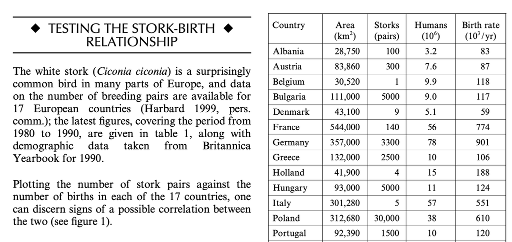

It’s meant as an educational paper, which is lists a sensible conclusion.

> The empirical relationship between the number of stork breeding pairs and human birth ratesin 17 European countries provides a non-trivial example of a correlation which is highly statistically significant, not immediately explicable and yet causally nonsensical

## New evidence for the Theory of the Stork

There’s another paper that goes a step further though. The “New evidence for the Theory of the Stork” paper by Höfer, Przyrembel and Verleger takes the full-on statire approach. You can find it [here](https://web.stanford.edu/class/hrp259/2007/regression/storke.pdf).

To quote the summary:

> A lack of statistical information on out-ofhospital deliveries in general is a severe handicap for further proof for the Theory of the Stork.

To prevent misinterpretation, the paper also comes with a huge warning on the frontpage.

> The intended value (disclaimer): This article is not intended to disprove the value of serious epidemiological investigations. It is an example of how studies based on popular belief and unsubstantiated theory, seconded by low quality references and supported by coincidental statistical association could lead to apparent scientific endorsement. Insofar it is a humorous case study for education in perinatal epidemiology.

The warning makes sense, especially when you have a look at the introduction.

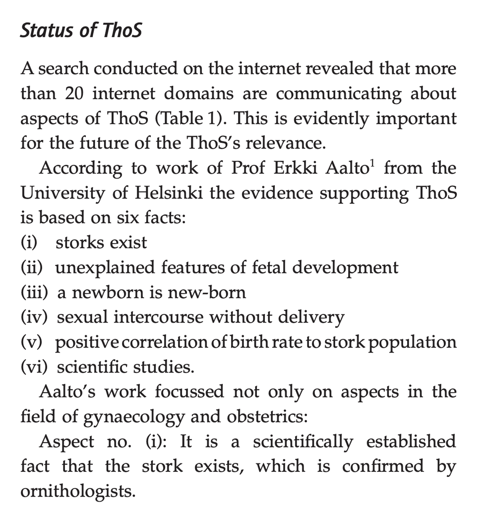

The paper even offers figures and disucssion!

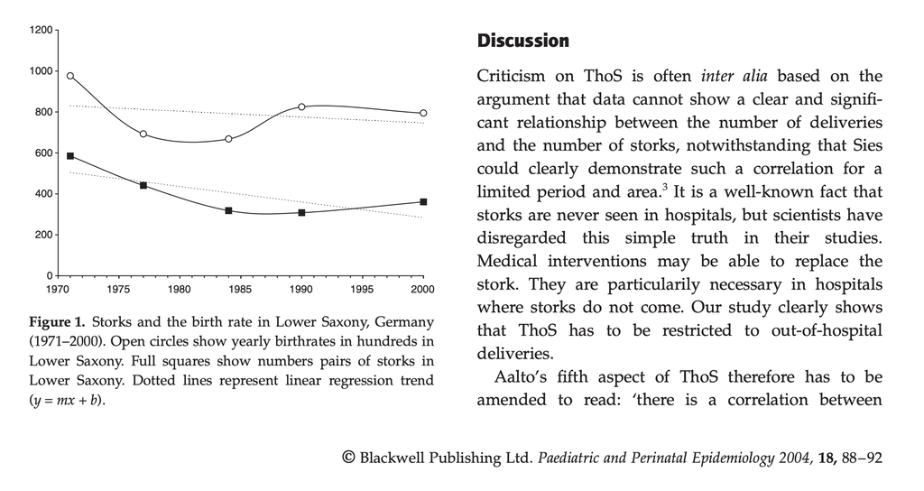

## Conclusion

Jokes aside, these two papers reminded me how statistics can sometimes also be a disservice. It’s a nice tool, but they can also help you claim nonsense.

Anyhoo, reading these papers got making a course on [statistical disservice on calmcode.io](https://calmcode.io/statistical-disservice/wunderlich.html).